# Gap markers, diluted tissue pools and the donor allele deficit

chr10 GENOTYPE runs A-C (huehuetenangensis unions), 1270808 (diploperennis), 1273053 (mexicana); 2026-10-16

Author

Fausto Rodríguez-Zapata

Published

October 16, 2026

## Why

Questions of the user, 2026-10-16, while the diploperennis partner runs D-F ran (`docs/runs/genotype_diploperennis_partners_chr10.md`):

- gap markers skip the witness veto, so how can they smooth the genotypes of notebook 06;
- whether the smoothing erases diluted signal, and what that means for mapping;
- whether the low donor allele frequency is selection against the donor, as in TeoNAM.

Inputs (not in git): small tables in `gap_markers_dilution/`, made by `agent/nb07/collect.sh` (log there) from the runs on hazel and from the measurement jobs 1332113 and 1332684; master copy in `/rsstu/users/r/rrellan/BZea/ZEAL/genotype/notebook_inputs/gap_markers_dilution/`; copy it next to this notebook to re-render. Lines are named by registry NIL id with the sample in parentheses.

## 1. Where the gap markers come from

A donor’s RTIGER markers are the union sites gap filling called ALT for it (Milestone 9a): its own tier-A sites and gap sites, discovered in other donors. Each gap marker, looked up in the donor’s own discovery (CRISP, then the witness veto, then the tiers):

| run | donor | markers | CRISP called other alleles | in discovery, tier B or C | not called by CRISP | removed by witness veto |
| --- | --- | --- | --- | --- | --- | --- |
| B | Zh.0020_P3 | 98,184 | 12 | 2,050 | 89,134 | 6,988 |
| B | Zh.0030_P4 | 104,016 | 48 | 4,212 | 54,069 | 45,686 |
| C | Zh.0020_P3 | 85,265 | 11 | 2,170 | 76,123 | 6,961 |
| C | Zh.0030_P4 | 90,488 | 42 | 4,145 | 43,456 | 42,844 |

Medians over the markers; tier from the donor’s BC1 pools counted at the union sites.

| run | donor | markers | tier A at the union (%) | BC1 reads | BC1 ALT reads | pools with ALT | LLR |
| --- | --- | --- | --- | --- | --- | --- | --- |
| B | Zh.0020_P3 | own | 99.3 | 28 | 9 | 3 | 20.3 |
| B | Zh.0020_P3 | gap | 92.6 | 24 | 7 | 3 | 18.1 |
| B | Zh.0030_P4 | own | 98.4 | 45 | 12 | 5 | 26.1 |
| B | Zh.0030_P4 | gap | 85.8 | 41 | 10 | 4 | 21.7 |
| C | Zh.0020_P3 | own | 99.2 | 28 | 9 | 3 | 20.3 |
| C | Zh.0020_P3 | gap | 92.5 | 24 | 7 | 3 | 17.9 |
| C | Zh.0030_P4 | own | 98.3 | 44 | 12 | 5 | 26.0 |
| C | Zh.0030_P4 | gap | 85.8 | 41 | 10 | 4 | 21.4 |

Most gap markers are sites the donor’s own CRISP never called (about 90 % for Zh.0020_P3, half for Zh.0030_P4); about 9 in 10 score tier A when the union is counted on the same BC1 reads (bcftools mpileup, MAPQ 20, base quality 20). So gap filling mostly adds sites the BC1 pools support, not promoted tier-B sites. For Zh.0030_P4, 44 % were removed by its witness veto: BC1 reads ALT, its lines do not.

## 2. Do the lines carry them

| run | donor | markers | n | with an ALT read in the lines (%) |
| --- | --- | --- | --- | --- |
| B | Zh.0020_P3 | own | 26,779 | 96.2 |
| B | Zh.0020_P3 | gap | 98,184 | 46.6 |
| B | Zh.0030_P4 | own | 36,975 | 92.3 |
| B | Zh.0030_P4 | gap | 104,016 | 13.7 |
| C | Zh.0020_P3 | own | 26,851 | 96.2 |
| C | Zh.0020_P3 | gap | 85,265 | 49.2 |
| C | Zh.0030_P4 | own | 36,997 | 92.3 |
| C | Zh.0030_P4 | gap | 90,488 | 14.5 |

A marker read only REF where its lines are in a donor state: probably REF in the donor.

| run | donor | markers | >= 5 reads from lines in donor state | no ALT read (%) |
| --- | --- | --- | --- | --- |
| B | Zh.0020_P3 | own | 7293 | 2.0 |
| B | Zh.0020_P3 | gap | 4210 | 6.2 |
| B | Zh.0030_P4 | own | 1024 | 5.9 |
| B | Zh.0030_P4 | gap | 368 | 19.6 |
| C | Zh.0020_P3 | own | 7275 | 1.9 |
| C | Zh.0020_P3 | gap | 4289 | 5.9 |
| C | Zh.0030_P4 | own | 1023 | 6.1 |
| C | Zh.0030_P4 | gap | 377 | 21.2 |

Run B: ALT % of the lines’ reads per segment state, own vs gap markers (run C within a point).

| donor | src | REF | HET | ALT |
| --- | --- | --- | --- | --- |
| Zh.0020_P3 | gap | 1.4 | 36.2 | 77.4 |
| Zh.0020_P3 | own | 2.6 | 40.7 | 78.3 |
| Zh.0030_P4 | gap | 0.4 | 31.3 | 81.9 |
| Zh.0030_P4 | own | 2.9 | 65.8 | 91.3 |

- Fewer gap markers have an ALT read in the lines, but read depth there is low; inside donor segments, Zh.0020_P3’s gap markers read ALT about as often as its own (HET 36 vs 41 %, ALT 77 vs 78 %).
- About 6 % of Zh.0020_P3’s testable gap markers (3x its own markers’ share) and a fifth of Zh.0030_P4’s read no ALT: false alleles for this donor. Zh.0030_P4 carries almost no chr10 introgression (notebook 06), so its test is weak.
- In REF segments gap markers are cleaner: 0.4-1.4 % ALT against 2.6-2.9 % at own markers.

## 3. Zh00203113 (PN9_SID806): what smoothing did

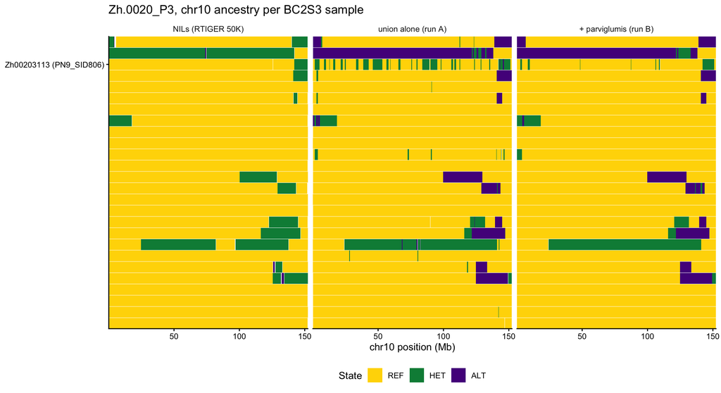

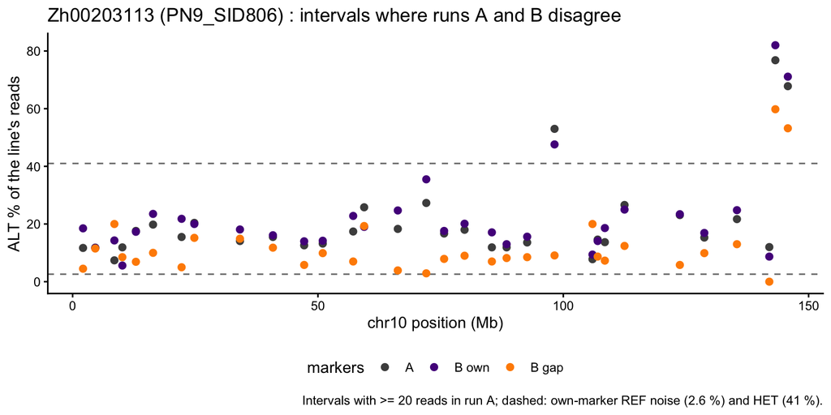

Line checks of the sample.

| run | segments | REF % ALT | HET % ALT | ALT % ALT |
| --- | --- | --- | --- | --- |
| alone | 25 | 5.3 | 24.0 | 70.3 |
| + parviglumis | 7 | 7.5 | 38.0 | NA |
| + mexicana | 8 | 7.4 | 38.1 | NA |

- Run A breaks 1.6-98 Mb into HET pieces; run B calls it REF. There the sample’s own markers read 14-25 % ALT, far above REF noise and below HET: about 0.18 donor allele frequency (/ 0.82, notebook 05), about 2 of the 6 plants HET.
- Gap markers read half that or less, so they pulled the stretch to REF and the ALT segment at 143-146 Mb to HET.
- The diluted signal is not lost: run B’s line checks fail the sample (REF 7.5 % ALT, 7 donor segments).

## 4. Diluted tissue pools across taxa

| taxon | lines | median REF % ALT | p90 | lines > 3 % | lines > 5 % | segments, > 3 % | segments, <= 3 % |
| --- | --- | --- | --- | --- | --- | --- | --- |
| huehuetenangensis | 61 | 1.3 | 2.7 | 4 | 1 | 1.5 | 0 |
| parviglumis | 601 | 1.3 | 2.7 | 41 | 5 | 3.0 | 1 |
| diploperennis | 253 | 1.7 | 3.5 | 37 | 5 | 3.0 | 1 |
| mexicana | 712 | 1.3 | 2.9 | 62 | 5 | 4.0 | 1 |

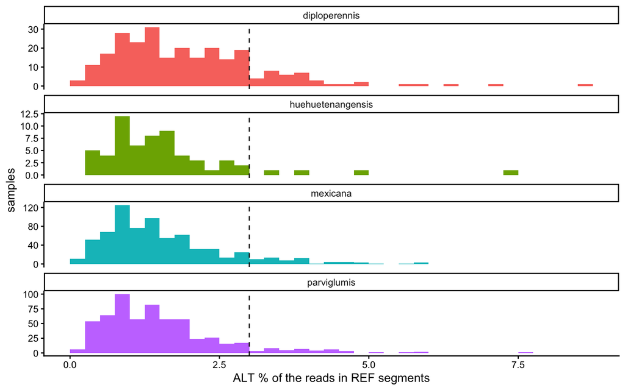

7-15 % of the samples read more than 3 % ALT in their REF segments, and those also have more donor segments. Read as pools of 6 plants where only some carry an authentic introgression (user, 2026-10-16), plus some low-depth noise.

## 5. The donor allele deficit

### Called and hidden

Donor allele frequency on chr10 (HET 0.5, ALT 1, by bp, mean over samples); hidden: REF % ALT above the taxon’s median sample, / 0.82.

| taxon | run | donors | lines | called (%) | hidden in REF segments (%) | together (%) | expected (%) |
| --- | --- | --- | --- | --- | --- | --- | --- |
| huehuetenangensis | B | 2 | 61 | 5.43 | 0.51 | 5.94 | 12.5 |
| parviglumis | B | 40 | 601 | 7.24 | 0.44 | 7.68 | 12.5 |
| diploperennis | 1270808 | 6 | 253 | 8.68 | 0.58 | 9.26 | 12.5 |
| mexicana | 1273053 | 42 | 712 | 9.34 | 0.43 | 9.77 | 12.5 |

Hiding diluted signal in REF segments costs about half a point; the deficit is 3-7 points.

### Against TeoNAM and SNP50K

Chen et al. (2019) Table 1, TeoNAM BC1S4 (expected 73.44 / 3.13 / 23.44 %, allele 25 %).

| population | RILs | W22 % | HET % | teosinte % | teosinte allele % (computed) |
| --- | --- | --- | --- | --- | --- |
| W22 x TIL01 | 223 | 75.8 | 7.7 | 16.0 | 19.85 |
| W22 x TIL03 | 270 | 75.5 | 8.1 | 16.2 | 20.25 |
| W22 x TIL11 | 219 | 76.3 | 7.6 | 15.6 | 19.40 |
| W22 x TIL14 | 235 | 75.7 | 9.4 | 14.6 | 19.30 |
| W22 x TIL25 | 310 | 77.6 | 8.0 | 14.2 | 18.20 |
| Composite | 1257 | 76.6 | 8.1 | 15.0 | 19.05 |

| set | calls | observed / expected | ratio |
| --- | --- | --- | --- |
| TeoNAM, 5 families, all chromosomes | per RIL | 19.1 / 25.0 | 0.76 |
| ZEAL huehuetenangensis, chr10 | zealgt (B) | 5.9 / 12.5 | 0.48 |
| ZEAL parviglumis, chr10 | zealgt (B) | 7.7 / 12.5 | 0.61 |
| ZEAL diploperennis, chr10 | zealgt (1270808) | 9.3 / 12.5 | 0.74 |
| ZEAL mexicana, chr10 | zealgt (1273053) | 9.8 / 12.5 | 0.78 |
| ZEAL diploperennis, chr10 (252 samples) | SNP50K RTIGER | 7.5 / 12.5 | 0.60 |
| ZEAL huehuetenangensis, chr10 (61 samples) | SNP50K RTIGER | 3.5 / 12.5 | 0.28 |
| ZEAL parviglumis, chr10 (381 samples) | SNP50K RTIGER | 5.2 / 12.5 | 0.42 |
| ZEAL mexicana, chr10 (571 samples) | SNP50K RTIGER | 6.3 / 12.5 | 0.50 |

The same direction as TeoNAM, where Chen et al. report “an excess of maize alleles” in all subpopulations; within a call set the taxa compare, across call sets only the direction. SNP50K sits lower partly because it calls donor-homozygous segments HET (notebook 06).

### Coverage, families and markers

Sample coverage and called chr10 donor allele frequency by coverage band.

| taxon | lines_in_sheets | median_cov | mean_cov | called_lines | freq_pct | cov0-0.5: n, freq_pct | cov0.5-1: n, freq_pct | cov1-2: n, freq_pct | cov2-up: n, freq_pct |
| --- | --- | --- | --- | --- | --- | --- | --- | --- | --- |
| diploperennis | 256 | 0.34 | 0.33 | 253 | 8.7 | 229, 8.5 | 24, 10.7 | 0, NA | 0, NA |
| huehuetenangensis | 61 | 0.29 | 0.29 | 61 | 5.4 | 60, 5.5 | 1, 0.0 | 0, NA | 0, NA |
| parviglumis | 606 | 0.42 | 0.42 | 601 | 7.2 | 390, 7.2 | 206, 7.4 | 5, 0.0 | 0, NA |
| mexicana | 722 | 0.40 | 0.41 | 715 | 9.6 | 587, 9.8 | 127, 8.7 | 1, 0.0 | 0, NA |

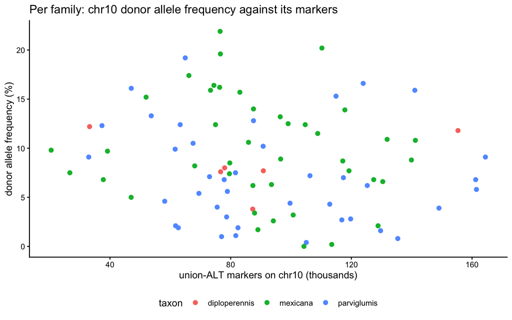

| taxon | families | median (%) | mean (%) | under 2 % | median markers | median BC1 coverage | Spearman freq ~ markers |
| --- | --- | --- | --- | --- | --- | --- | --- |
| diploperennis | 6 | 7.85 | 8.52 | 0 | 82652.0 | 5.34 | -0.14 |
| parviglumis | 40 | 6.50 | 7.22 | 7 | 82054.0 | 4.06 | -0.20 |
| mexicana | 42 | 9.30 | 9.92 | 3 | 88476.5 | 4.30 | -0.23 |

Line coverage is the same for parviglumis and mexicana (0.42x and 0.40x), and neither markers nor BC1 coverage predict a family’s frequency. parviglumis is lower through its whole family distribution, not through families without chr10 introgression.

### Along the chromosome and across chromosomes

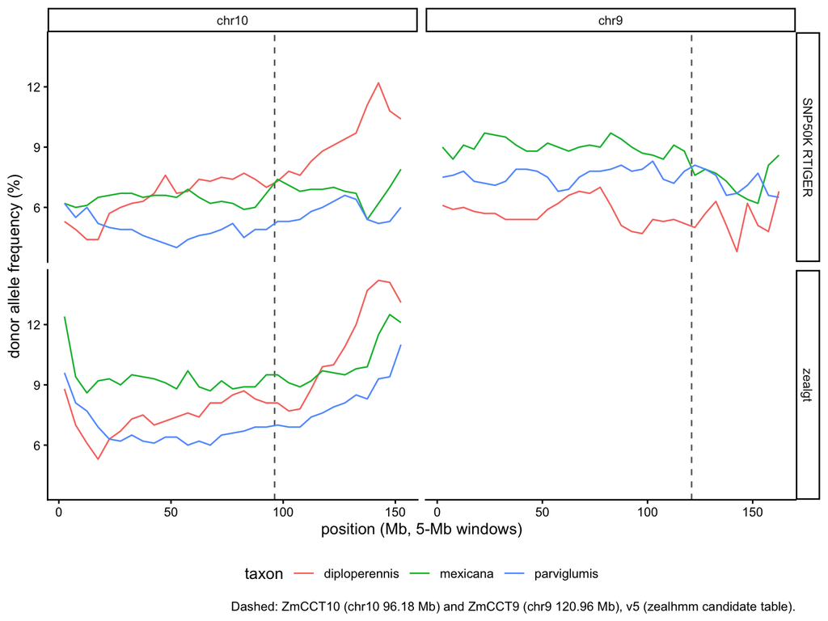

SNP50K RTIGER donor allele frequency (%) per chromosome.

| chr | diploperennis | huehuetenangensis | parviglumis | mexicana |
| --- | --- | --- | --- | --- |
| 1 | 4.2 | 5.4 | 4.8 | 6.5 |
| 2 | 7.1 | 4.5 | 8.9 | 9.8 |
| 3 | 6.3 | 9.5 | 5.7 | 7.2 |
| 4 | 2.4 | 5.3 | 6.7 | 6.3 |
| 5 | 1.7 | 2.5 | 7.3 | 5.3 |
| 6 | 3.9 | 4.8 | 5.9 | 5.3 |
| 7 | 3.9 | 4.1 | 8.2 | 6.5 |
| 8 | 6.4 | 7.7 | 8.4 | 6.3 |
| 9 | 5.5 | 3.7 | 7.5 | 8.5 |
| 10 | 7.5 | 3.5 | 5.1 | 6.5 |

- No parviglumis dip at ZmCCT10 or ZmCCT9; on chr10 it is lower along the whole chromosome.
- Across chromosomes parviglumis is higher than mexicana on chr4-8 and lower on chr1-3, 9, 10; equal over all ten (SNP50K 6.8 %).

### Tests of selection for the genome-wide genotypes

Planned, not run (2026-10-16). Each family (donor) is the unit: its samples share one donor gamete, and neighbouring windows share segments. A BC2S3 sample is the selfed progeny of one BC2S2 plant, so its pool estimates that parent’s dosage, and its calls are read at the BC2S2 level (84.4 % REF, 6.25 % HET, 9.4 % donor homozygous; donor allele 12.5 %). The neutral null for every test is the zealtiger pedigree simulation (BC1 pools, BC2, selfings, real map, each family’s pool and sample numbers), which carries the founder effect.

1. **Transmission, BC1 pool to BC2S3 (by frequency).** A BC1 sample is a pool of 6 independent BC1 plants, so its reads give the share of BC1 chromosomes carrying the donor allele at each site (about 25 % on average; 6 plants cover most of the donor genome), not each plant’s segments. One more backcross halves that share and selfing keeps it: per window and family, the donor frequency in the BC2S3 samples against half the pool’s, with the pedigree simulation as the null. A family is compared with its own ancestors, at the level of frequency. Assumes the family’s samples descend from the pooled plants in about equal numbers (to check in the records); the pools’ depth (3.5-5x for 12 haplotypes) makes per-site frequencies noisy, so only windows of many sites.
2. **Parallel change across families** (evolve-and-resequence). Selection moves all families at a locus the same way, drift moves each on its own: per window, a Cochran-Mantel-Haenszel test across families (observed vs expected donor allele count). All taxa together for selection in the B73 background, one taxon for adaptation.
3. **More spread than drift allows** (Lewontin-Krakauer / F<sub>ST</sub>-outlier style). The variance of donor frequency across loci under drift alone is set by the pedigree (plants advanced per generation); loci far outside the simulated spread are candidates.
4. **Segment ends and lengths near a selected locus.** Selection for the donor allele keeps longer donor segments around it (hitchhiking); selection against it piles up recombination breakpoints nearby, with donor segments stopping short of it. From the RTIGER segments; less affected by dilution than frequencies.
5. **Gametophytic factors.** Maize x teosinte crosses carry gametophyte loci that bias transmission from heterozygotes (*Ga1* and *Tcb1* on chr4, *Ga2* on chr5): positive controls for distortion. Which taxa carry which alleles is to be checked in the literature.
6. **Association with fitness traits.** A QTL scan (family covariate) for seed set, germination, vigour or flowering time, if scored, for loci the breeding could have selected on.
7. **Generation by environment.** If generations alternated between the PV23 winter nursery (short days) and summer nurseries (long days), the photoperiod hypothesis predicts locus-specific changes that differ between environments. Needs the nursery history and more than one genotyped generation.
8. **HET to donor-homozygous ratio, per locus and genome-wide**, against BC2S2’s 0.67 (6.25 / 9.375; earlier skim analyses about 2:1). With the allele frequency it separates selection against donor homozygotes (recessive deleterious alleles, as Chen et al. suggest near *tga1*: the ratio rises well above 0.67, the frequency falls less) from additive selection against the allele (HET and homozygous classes shrink together).
9. **Divergence between taxa.** Per-family donor allele frequency, parviglumis (40) vs mexicana (42), genome-wide and per chromosome; permutation of taxon labels across families, or a mixed model (sample frequency ~ taxon + (1 | family)).

Where the reading fails, and how it is guarded:

- **Diluted pools:** when the 6 sampled plants do not represent their sibship (Zh00203113 (PN9_SID806)), the pool does not measure the parent’s dosage; the line checks flag them (REF % ALT > 3).
- **State calls:** HET called where the pool reads near-homozygous ALT inflates the ratio of test 8 (SNP50K: Zh.0020_P3 0.1 % donor homozygous against 6.8-7.1 % in the unions), so test 8 uses zealgt calls.
- **Detection bias:** detection that differs by taxon or region mimics selection. A caller calibration per taxon (simulated reads, known truth), including TIL01 reads (parviglumis mapping bias not measured), or comparisons within one call set and taxon. Test 1 is the least affected (BC1 and samples share the reference bias).
- **Data:** all tests need the genome-wide zealgt genotypes; test 1 also needs the BC1 pools’ donor allele counts at the markers (the union counts already hold them) and the pedigree link from pooled plants to samples.

- Test 8 without pools: HET to teosinte-homozygous ratio expected 0.13 (3.13 / 23.44), observed 0.54; per locus, where the excess concentrates (Chen et al.: 4S near *tga1*).
- Tests 2-5 per family and across the five; zealhmm’s per-family χ² outlier lists against BC1S4 (`agent/qtl_permap_run.log`, 318-421 flagged markers per family) as a first set of candidates. Test 6 with the 22 published traits if fitness proxies are among them. Test 1 only if earlier generations were genotyped; test 9 depends on the accessions’ taxa (to check in the paper).
- Loci distorted in both TeoNAM (W22 background) and ZEAL (B73 background) point to selection on the teosinte allele itself; loci in one population only, to that background or to a detection artefact.

## 6. Notes (2026-10-16)

- **Gap markers are mostly CRISP misses**, not promoted tier-B sites: per-donor CRISP leaves out sites its own BC1 reads score tier A at the union. One CRISP over all BC1 pools and every donor’s witness pool would be the principled form (user); a separate test (`agent/diplo_chr10/joint_crisp_test_plan.md`).
- **For mapping, calling diluted stretches REF is preferred** (user): it puts the error in the large REF class. SNP50K RTIGER calls the same stretches REF: of the bp our runs call REF in samples with REF % ALT > 3, SNP50K calls 96-99 % REF and 1-4 % HET (clean samples: 99.7-99.9 % REF; table below). Unlike SNP50K, which calls donor-homozygous segments HET, the union runs keep the classes separate (segment ALT % nearer 0 / 50 / 100). For choosing samples at a candidate gene the line checks flag the diluted ones (REF % ALT > 3), per sample, not per position: a windowed flag would be a design change.

SNP50K RTIGER states over the bp our runs call REF (run B, 1270808, 1273053; samples in both).

| taxon | samples | group | SNP50K REF (%) | SNP50K HET (%) | SNP50K ALT (%) |
| --- | --- | --- | --- | --- | --- |
| diploperennis | 215 | REF % ALT <= 3 | 99.7 | 0.3 | 0 |
| diploperennis | 37 | REF % ALT > 3 | 97.6 | 2.4 | 0 |
| huehuetenangensis | 57 | REF % ALT <= 3 | 99.9 | 0.1 | 0 |
| huehuetenangensis | 4 | REF % ALT > 3 | 98.8 | 1.2 | 0 |
| parviglumis | 351 | REF % ALT <= 3 | 99.9 | 0.1 | 0 |
| parviglumis | 30 | REF % ALT > 3 | 99.0 | 1.0 | 0 |
| mexicana | 518 | REF % ALT <= 3 | 99.9 | 0.1 | 0 |
| mexicana | 53 | REF % ALT > 3 | 96.4 | 3.6 | 0 |

- **Diluted pools are authentic introgressions carried by some of the 6 sampled plants** (user); 6 of the 12 planted plants estimate the bulk’s allele frequency well. If the phenotype came from the same plants, their dose is fractional, and neither REF nor HET states it.
- **The donor allele deficit has the direction of TeoNAM’s**; dilution explains half a point of 3-7. On chr10 neither a photoperiod-gene dip nor a consistent lowland (parviglumis) deficit across chromosomes is seen: the parviglumis chr10 shift is about 2.4 standard errors of the family mean and other chromosomes differ by 1-2 points in both directions. The genome-wide run decides.
- **Mexicana above parviglumis on chr10, in both call sets** (user, 2026-10-16): zealgt 9.3 vs 7.2 % (gap 2.1 points), SNP50K on the same samples 6.3 vs 5.2 % (gap 1.1), mexicana higher in most 5-Mb windows from 10 to 110 Mb. Genome-wide SNP50K shows no difference (6.8 vs 6.8 %; the sign changes between chromosomes). Not yet known for zealgt genome-wide.
- **Tests, once zealgt genotypes cover the genome**: section 5, “Tests of selection for the genome-wide genotypes” (divergence between taxa, the overall deficit after a caller calibration per taxon, per-window distortion shared by all taxa or in one only, with Inv4m as the first check, zealhmm `analysis/zeal-inv4m-rtiger-genotype.qmd`).